# Use of the ‘pupR’ package for model-based estimation of northern fur seal pup production

Devin Johnson, Rod Towell, and Jason Baker

This guide provides a step-by-step code demonstration to use the `pupR` package as `tidyverse` group of packages for estimating northern fur seal pup abundance. First, load all the necessary packages:

## Raw data structure

We begin with data import and rearragement for optimal model fitting. The 2016 NFS pup data can be accessed by the user by typeing the following code to see where the example data is stored:

```r
library(pupR)
show_data_loc()
```

```
## Raw example data located in the following directory:
## /Users/devin.johnson/Library/R/pupR/raw_data/
```

The data used for this process must look like the 2 data sets in the included directory. The example data may be read into the current `R` environemtnt using the following command:

```r
load_demo_data()
head(shear_2016_snp)
```

```
##   rookery  X0  X1  X2  X3  X4  X5  X6  X7  X8 X9 X10 X11 X12 X13 X14
## 1     LUK  NA 224  94  NA  NA  NA  NA  NA  NA NA  NA  NA  NA  NA  NA
## 2     KIT  21  40  60  85  91  66  NA  NA  NA NA  NA  NA  NA  NA  NA
## 3     REE  NA 108 211 114 106  84  NA 162 174 72  78   6  NA  NA  NA
## 4     GOR  NA 153  98 168  70 156 151  NA  NA NA  NA  NA  NA  NA  NA
## 5     ARD  NA  75  NA  NA  NA  NA  NA  NA  NA NA  NA  NA  NA  NA  NA
## 6     MOR 108 146 144 154  89 175 115  NA  NA NA  NA  NA  NA  NA  NA
```

```r
head(shear_2016_sng)
```

```
##   rookery  X1  X2  X3  X4 X5
## 1     SOU  98 129 128  NA NA
## 2     NOR 108 166 176 111 61
## 3     ERE 246  NA  NA  NA NA
## 4     ECL 304 146  NA  NA NA
## 5     STA  64  12  NA  NA NA
## 6     SGZ 150  NA  57  NA NA
```

```r
head(resight_2016_snp)
```

```
##      date rookery section obs resample count
## 1 8/12/16     MOR       0  RT        1     2
## 2 8/12/16     MOR       0  RT        1     3
## 3 8/12/16     MOR       0  RT        1     0
## 4 8/12/16     MOR       0  RT        1     2
## 5 8/12/16     MOR       0  RT        1     1
## 6 8/12/16     MOR       0  RT        1     4
```

```r
head(resight_2016_sng)
```

```
##      date rookery section obs resample count
## 1 8/18/16     ECL       1 JTS        1     3
## 2 8/18/16     ECL       1 JTS        1     4
## 3 8/18/16     ECL       1 JTS        1     2
## 4 8/18/16     ECL       1 JTS        1     4
## 5 8/18/16     ECL       1 JTS        1     1
## 6 8/18/16     ECL       1 JTS        1     0
```

Note that this is exactly how it is read in from the .csv files. To createw these files, I just cut the appropriate sections out of the `SNPdata2016.xlsx` and `SNGdata2016.xlsx` files. The worksheets contailing this data are the pups sheared and resampling sheets. The sheet heading, etc. seem to be different from year-to-year and between island, so, it is up the user to get the .csv files necessary into the same forms. Note, **column headings are important** and must be exactly the same for the following code to work. However, it is note necessary for the model fitting if you can change the data munging code appropriately. Also, note that the ‘X’ in the shearing data columns was auomatically put there by `R`, the raw data just has the section numbers as column names.

## Data munging

### Combining and normalizing

Now we use the new data packages in `R` to rearrange the data to use the `pupR` code to fit the models. We first have to turn the shearing data vertical rather than horizontal.

```r
library(tidyverse)
# St. Paul shearing data
shear_2016_snp %>% gather(section, M, -rookery) %>%
  filter(!is.na(M)) %>%
  mutate(section = sapply(strsplit(section, "X", fixed=T), function(x)x[2])) %>%
  mutate(island = "snp") %>% arrange(rookery, section) -> shear_2016_snp

# St. George shearing data
shear_2016_sng %>% gather(section, M, -rookery) %>%
  filter(!is.na(M)) %>%
  mutate(section = sapply(strsplit(section, "X", fixed=T), function(x)x[2])) %>%
  mutate(island = "sng") %>% arrange(rookery, section) -> shear_2016_sng

rbind(shear_2016_sng, shear_2016_snp) -> shear_2016

head(shear_2016)
```

```
##   rookery section   M island
## 1     ECL       1 304    sng
## 2     ECL       2 146    sng
## 3     ERE       1 246    sng
## 4     NOR       1 108    sng
## 5     NOR       2 166    sng
## 6     NOR       3 176    sng
```

Now, we’ll have to sum the resight counts within each section. For the basic occasion-observer model we will then sum over all resight counts within the rookery for each observer and occasion.

```r
# St. Paul resight data
resight_2016_snp %>% group_by(rookery, section, resample, obs) %>%
  summarise(., m=sum(count), u=as.integer(n()*25 - m)) %>% ungroup() %>%
  mutate(island="snp") %>%
  as.data.frame() -> resight_2016_snp

# St. George resight data
resight_2016_sng %>% group_by(rookery, section, resample, obs) %>%
  summarise(., m=sum(count), u=as.integer(n()*25 - m)) %>% ungroup() %>%
  mutate(island="sng") %>%
  as.data.frame() -> resight_2016_sng

rbind(resight_2016_sng, resight_2016_snp) -> resight_2016

head(resight_2016)
```

```
##   rookery section resample obs  m   u island
## 1     ECL       1        1 JDB 54 471    sng
## 2     ECL       1        1 JTS 49 476    sng
## 3     ECL       1        2 JDB 63 562    sng
## 4     ECL       1        2 JTS 45 455    sng
## 5     ECL       2        1 JDB 33 392    sng
## 6     ECL       2        1 JTS 39 386    sng
```

### Quality control

Now we will do a little quality control by checking that all the rookery and sections designations are the same in both the resight and shearing data.frames

```r
shear_sec = transmute(shear_2016, rook_sec=paste(island, rookery, section))[[1]]
resight_sec =  transmute(resight_2016, rook_sec=paste(island, rookery, section))[[1]]

# Check for same section
all(resight_sec %in% shear_sec)
```

```
## [1] FALSE
```

```r
all(shear_sec %in% resight_sec)
```

```
## [1] FALSE
```

Therefore we have some mismatches in section and rookery classification. Let find out which ones. These are the sections that are in the resight data, but are missing from the shearing data:

```r
unique(resight_sec[!(resight_sec%in%shear_sec)])
```

```
## [1] "sng SGZ 2"    "snp REE 67"   "snp REE 1011"
```

Looks like the number of shear marks for SGZ section 2 were combined with section 1, but, resights were still based on all 3 sections. So, because there does not seem to be good recorded separation between sections 1 and 2 at SGZ, 6 and 7 at REE, and 10 and 11 at REE, we will combine those into a single section in both data.frames.

```r
resight_2016 %>%
  mutate(section_orig=as.character(section), section=ifelse(island=='sng' & rookery=='SGZ' & section_orig%in%c('1','2'), '1/2', section_orig)) %>%
  mutate(section=ifelse(island=='snp' & rookery=='REE' &section_orig%in%c('6','7','67'), '6/7', section)) %>%
  mutate(section=ifelse(island=='snp' & rookery=='REE' & section_orig%in%c('10','11','1011'), '10/11', section)) -> resight_2016

shear_2016 %>%
 mutate(section_orig=as.character(section), section=ifelse(island=='sng' & rookery=='SGZ' & section_orig%in%c('1','2'), '1/2', section_orig)) %>%
  mutate(section=ifelse(island=='snp' & rookery=='REE' &section_orig%in%c('6','7','67'), '6/7', section)) %>%
  mutate(section=ifelse(island=='snp' & rookery=='REE' & section_orig%in%c('10','11','1011'), '10/11', section)) -> shear_2016
```

In the `shear_2016` data we have some sections where shear marks were put out, but no resights were recorded.

```r
unique(shear_sec[!(shear_sec%in%resight_sec)])
```

```
## [1] "sng STA 2" "snp REE 7"
```

Looks like the resighters only recorded `section=1` for resampling at STA. Therefore, all of STA will be combined into 1 section, `1/2`.

```r
resight_2016 %>%
  mutate(section=ifelse(island=='sng' & rookery=='STA' & section_orig%in%c('1','2'), '1/2', section)) -> resight_2016

shear_2016 %>%
 mutate(section=ifelse(island=='sng' & rookery=='STA' & section_orig%in%c('1','2'), '1/2', section)) -> shear_2016
```

Now we can check again to make sure all the sections line up

```r
shear_sec = transmute(shear_2016, rook_sec=paste(island, rookery, section))[[1]]
resight_sec =  transmute(resight_2016, rook_sec=paste(island, rookery, section))[[1]]

# Check for same section
all(resight_sec %in% shear_sec)
```

```
## [1] TRUE
```

```r
all(shear_sec %in% resight_sec)
```

```
## [1] TRUE
```

Alright, everything checks out with sections. Now let’s make sure there is consistancy with respect to observers.

```r
unique(resight_2016$obs)
```

```
## [1] JDB JTS RRR RT
## Levels: JDB JTS RRR RT
```

Looks good. I know all those people. Now, let’s go back and make sure all the counts are summed over the new combined sections we’ve defined.

```r
resight_2016 %>% group_by(island, rookery, section, resample, obs) %>%
  summarise(m=sum(m), u=sum(u)) %>% ungroup() %>%
  mutate(island=factor(island), rookery=factor(rookery), section=factor(section), resample=factor(resample)) %>%
  as.data.frame() %>% droplevels() -> resight_2016

shear_2016 %>% group_by(island, rookery, section) %>%
  summarise(M=sum(M)) %>% ungroup() %>% as.data.frame() %>% droplevels() -> shear_2016
```

The full resulting data is given in the last section ‘Data appendix.’

## Model fitting with ‘pupR’

Now we can use the data we just constructed to fit a mark-resight model where detection probablities vary be occasion and observer.

## First steps: An observer by occasion model

In this model we seek to account for occasion and observer variablility in the pup detection process. The model is described as follows. Each rookery will be treated separatey, so the description presented here is for a single rookery. The estimates of island total pup production will based on the sum of the rookery estimates.

### Model description

First, some notation. The following are the observed data

- $M$ = The total number of shear marked pups
- $m_{ij}$ = number of marked pups counted by observer $i$ on occasion $j$
- $u_{ij}$ = number of unmarked pups counted by observer $i$ on occation $j$

Now, the parameters of the model are

- $U$ = The total number of unmarked pups in the population
- $N$ = total pup abundance ($N=M+U$)
- $\delta_{ij}$ = probablility that a pup (marked or unmarked) is counted by observer $i$ on occasion $j$
- $\tau$ = probability that a pup is shear marked

This model can then be written as the product binomial likelihood
$$[U, \boldsymbol{\delta}, \tau|M, \mathbf{m}, \mathbf{u}] \propto [M|U, \tau]\times \prod_{i,j}\left\{[m_{ij}|M, \delta_{ij}]\times [u_{ij}|U, \delta_{ij}]\right\},$$
where

- $[M|U, \tau] = Binomial(M|M+U, \tau)$
- $[m_{ij}|M, \delta_{ij}] = Binomial(m_{ij}|M, \delta_{ij})$
- $[u_{ij}|U, \delta_{ij}] = Binomial(u_{ij}|U, \delta_{ij})$.

To make the optimization of the likelihood easier, I reparameterized the model as follows:

- $\beta_{ij} = \mbox{logit}(\delta_{ij})$
- $\alpha = \mbox{logit}(\tau)$
- $\theta = \log(U)$ where $\theta$ is continuous.

Inference was obtained via MLE using the Hessian matrix of the likelihood for calculation of the appropriate $SE$s. To estimate pup production I used
$$\hat N = \hat U + M,$$
thus, $SE(\hat N) = SE(\hat U)$.

### A little more data manipulation

Because I am looking at variation in detection at just the observer by occasion level a little more data manipulation is in order to sum the total number of sheared pups to the rookery level.

```r
shear_2016 %>% mutate(island=factor(island)) %>% group_by(island, rookery) %>% summarise(M = sum(M)) %>% ungroup() -> shear_2016_oo
resight_2016 %>% group_by(island, rookery, resample, obs) %>% summarize(m=sum(m), u=sum(u)) %>% ungroup() -> resight_2016_oo
shear_2016_oo
```

```
## # A tibble: 19 × 3
##    island rookery     M
##    <fctr>  <fctr> <int>
## 1     sng     ECL   450
## 2     sng     ERE   246
## 3     sng     NOR   622
## 4     sng     SGZ   207
## 5     sng     SOU   355
## 6     sng     STA    76
## 7     snp     ARD    75
## 8     snp     GOR   796
## 9     snp     KIT   363
## 10    snp     LUK   318
## 11    snp     LZA   608
## 12    snp     MOR   931
## 13    snp     PCL   658
## 14    snp     POL   321
## 15    snp     REE  1115
## 16    snp     TOL   911
## 17    snp     VOS  1546
## 18    snp     ZAP   906
## 19    snp     ZAR   411
```

```r
resight_2016_oo
```

```
## # A tibble: 78 × 6
##    island rookery resample    obs     m     u
##    <fctr>  <fctr>   <fctr> <fctr> <int> <int>
## 1     sng     ECL        1    JDB    87   863
## 2     sng     ECL        1    JTS    88   862
## 3     sng     ECL        2    JDB    99   801
## 4     sng     ECL        2    JTS    76   674
## 5     sng     ERE        1    JDB    59   691
## 6     sng     ERE        1    JTS    45   505
## 7     sng     ERE        2    JDB    51   524
## 8     sng     ERE        2    JTS    44   506
## 9     sng     NOR        1    JDB   145  1180
## 10    sng     NOR        1    JTS   144  1406
## # ... with 68 more rows
```

Wasn’t that easy using `dplyr`! I’ll group the two data sets, `shear_2016_oo` and `resight_2016` into a single data set where rows are based on island and rookery. That way I can apply the model fitting to each roookery at once using the functions in the `purrr` package.

```r
resight_2016_oo %>% group_by(island, rookery) %>% nest() %>%
left_join(shear_2016_oo) -> resight_2016_oo
resight_2016_oo
```

```
## # A tibble: 19 × 4
##    island rookery             data     M
##    <fctr>  <fctr>           <list> <int>
## 1     sng     ECL <tibble [4 × 4]>   450
## 2     sng     ERE <tibble [4 × 4]>   246
## 3     sng     NOR <tibble [4 × 4]>   622
## 4     sng     SGZ <tibble [6 × 4]>   207
## 5     sng     SOU <tibble [4 × 4]>   355
## 6     sng     STA <tibble [4 × 4]>    76
## 7     snp     ARD <tibble [4 × 4]>    75
## 8     snp     GOR <tibble [4 × 4]>   796
## 9     snp     KIT <tibble [4 × 4]>   363
## 10    snp     LUK <tibble [4 × 4]>   318
## 11    snp     LZA <tibble [4 × 4]>   608
## 12    snp     MOR <tibble [4 × 4]>   931
## 13    snp     PCL <tibble [4 × 4]>   658
## 14    snp     POL <tibble [4 × 4]>   321
## 15    snp     REE <tibble [4 × 4]>  1115
## 16    snp     TOL <tibble [4 × 4]>   911
## 17    snp     VOS <tibble [4 × 4]>  1546
## 18    snp     ZAP <tibble [4 × 4]>   906
## 19    snp     ZAR <tibble [4 × 4]>   411
```

Notice that there is a row for every (island, rookery) combination. The resample counts are in the `data` column in which each entry is itself a data set. We can examine these resight data sets just like selecting an entry in a data frame, e.g., for East Reef rookery the resight data is

```r
filter(resight_2016_oo, rookery=="ERE") %>% select(data) %>% .[[1]]
```

```
## [[1]]
## # A tibble: 4 × 4
##   resample    obs     m     u
##     <fctr> <fctr> <int> <int>
## 1        1    JDB    59   691
## 2        1    JTS    45   505
## 3        2    JDB    51   524
## 4        2    JTS    44   506
```

Note that you have to use the double brackets because the data is actually contained in a single element list. To access the object in the first list element, you need to have the double brackets. we can look at the object that we get with out the double brackets

```r
filter(resight_2016_oo, rookery=="ERE") %>% select(data) -> x
str(x)
```

```
## Classes 'tbl_df', 'tbl' and 'data.frame':    1 obs. of  1 variable:
##  $ data:List of 1
##   ..$ :Classes 'tbl_df', 'tbl' and 'data.frame': 4 obs. of  4 variables:
##   .. ..$ resample: Factor w/ 3 levels "1","2","3": 1 1 2 2
##   .. ..$ obs     : Factor w/ 4 levels "JDB","JTS","RRR",..: 1 2 1 2
##   .. ..$ m       : int  59 45 51 44
##   .. ..$ u       : int  691 505 524 506
```

### Fitting the model

The function that fits this particular model is `fit_oo` and we will fit the model to each rookery with the mapping functions of the `purrr` package. First, you need to create a function that will be applied to each row of the `resight_2016_oo` data set.

```r
resight_2016_oo %>% mutate(., fit = pmap(.,fit_oo)) -> resight_2016_oo
resight_2016_oo
```

```
## # A tibble: 19 × 5
##    island rookery             data     M        fit
##    <fctr>  <fctr>           <list> <int>     <list>
## 1     sng     ECL <tibble [4 × 4]>   450 <list [3]>
## 2     sng     ERE <tibble [4 × 4]>   246 <list [3]>
## 3     sng     NOR <tibble [4 × 4]>   622 <list [3]>
## 4     sng     SGZ <tibble [6 × 4]>   207 <list [3]>
## 5     sng     SOU <tibble [4 × 4]>   355 <list [3]>
## 6     sng     STA <tibble [4 × 4]>    76 <list [3]>
## 7     snp     ARD <tibble [4 × 4]>    75 <list [3]>
## 8     snp     GOR <tibble [4 × 4]>   796 <list [3]>
## 9     snp     KIT <tibble [4 × 4]>   363 <list [3]>
## 10    snp     LUK <tibble [4 × 4]>   318 <list [3]>
## 11    snp     LZA <tibble [4 × 4]>   608 <list [3]>
## 12    snp     MOR <tibble [4 × 4]>   931 <list [3]>
## 13    snp     PCL <tibble [4 × 4]>   658 <list [3]>
## 14    snp     POL <tibble [4 × 4]>   321 <list [3]>
## 15    snp     REE <tibble [4 × 4]>  1115 <list [3]>
## 16    snp     TOL <tibble [4 × 4]>   911 <list [3]>
## 17    snp     VOS <tibble [4 × 4]>  1546 <list [3]>
## 18    snp     ZAP <tibble [4 × 4]>   906 <list [3]>
## 19    snp     ZAR <tibble [4 × 4]>   411 <list [3]>
```

Now there is a fitted model associated with each row of the resight data, e.g., in the first row

```r
resight_2016_oo[1,5][[1]]
```

```
## [[1]]
## [[1]]$par
##     theta     alpha     JDB_1     JTS_1     JDB_2     JTS_2
##  8.321774 -2.212557 -1.335646 -1.335720 -1.403501 -1.625943
##
## [[1]]$vcv
##              theta        alpha        JDB_1        JTS_1        JDB_2
## theta  0.002546329 -0.002546321 -0.002898787 -0.002898743 -0.002859188
## alpha -0.002546321  0.005011760  0.002898779  0.002898734  0.002859180
## JDB_1 -0.002898787  0.002898779  0.004629459  0.003299982  0.003254952
## JTS_1 -0.002898743  0.002898734  0.003299982  0.004629415  0.003254902
## JDB_2 -0.002859188  0.002859180  0.003254952  0.003254902  0.004594647
## JTS_2 -0.002746704  0.002746696  0.003126898  0.003126850  0.003084183
##              JTS_2
## theta -0.002746704
## alpha  0.002746696
## JDB_1  0.003126898
## JTS_1  0.003126850
## JDB_2  0.003084183
## JTS_2  0.004558467
##
## [[1]]$logLik
## [1] -34.12472
```

The `get_IS_sample` function can now be use to a sample from the posterior distribution of the real parameters for each rookery.

```r
resight_2016_oo %>% mutate(SIR=pmap(., get_IS_sample)) -> resight_2016_oo
```

```r
resight_2016_oo %>% mutate(summary=pmap(., summarize_oo)) -> resight_2016_oo
select(resight_2016_oo, island, rookery, summary) %>% unnest() %>% as.data.frame() -> results_tbl
```

Here are the Bayes estimates of pup production by rookery and compare the results to the traditional way to estimate production.

```r
pupbull = read.csv("/Users/devin.johnson/research/projects/methodology_devel/model_based_pup_production/work/PUPBULL_2016.csv")
filter(results_tbl, parameter=="N") %>% left_join(pupbull, by=c("rookery" = "RCOD")) %>%
  mutate(estimate=ifelse(!is.na(DEADPUPS), estimate+DEADPUPS, estimate)) %>%
  mutate(CI.lower=ifelse(!is.na(DEADPUPS), CI.lower+DEADPUPS, CI.lower)) %>%
  mutate(CI.upper=ifelse(!is.na(DEADPUPS), CI.upper+DEADPUPS, CI.upper)) %>%
  select(-YEAR, -ROOKERY, -contains("BULLS")) -> N_tbl
N_tbl
```

```
##    island rookery parameter estimate  se CI.lower CI.upper DEADPUPS
## 1     sng     ECL         N     4570 210     4163     4960       NA
## 2     sng     ERE         N     3028 184     2685     3400       25
## 3     sng     NOR         N     6299 216     5904     6758       81
## 4     sng     SGZ         N     1860  76     1716     2010       NA
## 5     sng     SOU         N     3852 177     3502     4192       41
## 6     sng     STA         N      780  77      639      937       NA
## 7     snp     ARD         N      628  66      510      761       NA
## 8     snp     GOR         N     7096 271     6596     7638       NA
## 9     snp     KIT         N     3518 173     3201     3873       NA
## 10    snp     LUK         N     2591 117     2362     2810      103
## 11    snp     LZA         N     5272 208     4882     5697       NA
## 12    snp     MOR         N     7805 183     7426     8138      174
## 13    snp     PCL         N     6504 182     6159     6857       NA
## 14    snp     POL         N     3175 133     2926     3446       NA
```

[output cut: 25 more lines]

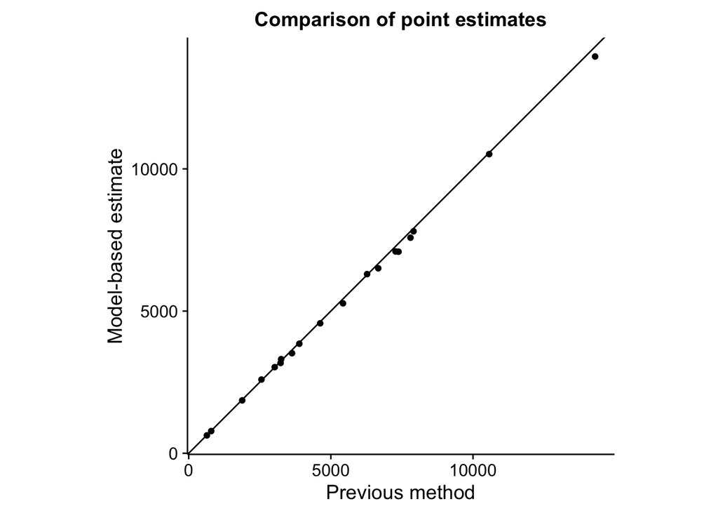

```r
ggplot(data=N_tbl) + geom_point(aes(x=PUPSBORN, y=estimate)) + coord_equal() + geom_abline(intercept = 0, slope = 1) + xlab("Previous method") + ylab("Model-based estimate") + ggtitle("Comparison of point estimates")
```

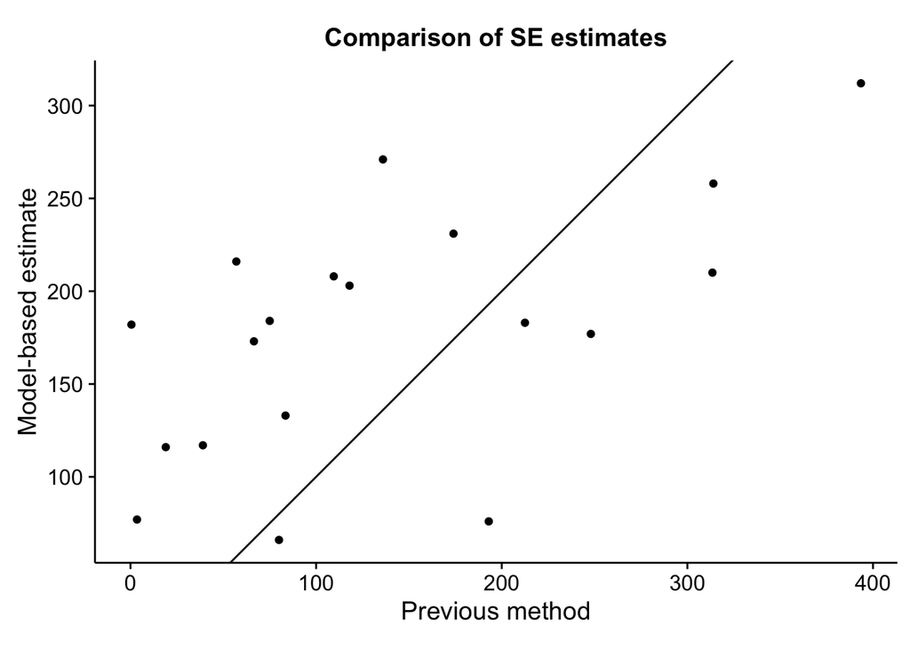

```r
ggplot(data=N_tbl) + geom_point(aes(x=SEP, y=se)) + coord_equal() + geom_abline(intercept = 0, slope = 1) + xlab("Previous method") + ylab("Model-based estimate") + ggtitle("Comparison of SE estimates")
```

Here are the estimates of $\delta$:

```r
filter(results_tbl, !parameter%in%c("N","tau"))
```

```
##    island rookery   parameter  estimate          se  CI.lower  CI.upper
## 1     sng     ECL delta_JDB_1 0.2083330 0.011377570 0.1861339 0.2297150
## 2     sng     ECL delta_JTS_1 0.2082884 0.011315664 0.1874402 0.2313417
## 3     sng     ECL delta_JDB_2 0.1972122 0.010833680 0.1765416 0.2190711
## 4     sng     ECL delta_JTS_2 0.1644383 0.009354653 0.1442692 0.1814432
## 5     sng     ERE delta_JDB_1 0.2505932 0.017110639 0.2192117 0.2857682
## 6     sng     ERE delta_JTS_1 0.1838573 0.013035988 0.1598934 0.2095090
## 7     sng     ERE delta_JDB_2 0.1921587 0.013874811 0.1643338 0.2178673
## 8     sng     ERE delta_JTS_2 0.1838837 0.013531747 0.1589400 0.2114060
## 9     sng     NOR delta_JDB_1 0.2134437 0.008991611 0.1959083 0.2308842
## 10    sng     NOR delta_JTS_1 0.2495495 0.010270138 0.2299610 0.2696299
## 11    sng     NOR delta_JDB_2 0.2173760 0.009104471 0.1997147 0.2345627
## 12    sng     NOR delta_JTS_2 0.2373811 0.009801168 0.2186736 0.2566931
## 13    sng     SGZ delta_JDB_1 0.3501214 0.018172676 0.3144571 0.3854108
## 14    sng     SGZ delta_JTS_1 0.3500958 0.017959455 0.3147056 0.3843392
```

[output cut: 64 more lines]

And, finally, $\tau$ the probability that a pup was sheared in each rookery

```r
filter(results_tbl, parameter=="tau")
```

```
##    island rookery parameter   estimate          se   CI.lower  CI.upper
## 1     sng     ECL       tau 0.09864727 0.006257489 0.08572546 0.1100739
## 2     sng     ERE       tau 0.08209930 0.006988685 0.06899728 0.0965124
## 3     sng     NOR       tau 0.10007835 0.005189491 0.08961765 0.1099416
## 4     sng     SGZ       tau 0.11157978 0.008505040 0.09579346 0.1289376
## 5     sng     SOU       tau 0.09336718 0.006380867 0.08090488 0.1060124
## 6     sng     STA       tau 0.09838713 0.014418611 0.07051521 0.1259920
## 7     snp     ARD       tau 0.12069367 0.017985637 0.08710709 0.1572875
## 8     snp     GOR       tau 0.11231302 0.005834882 0.10150917 0.1243331
## 9     snp     KIT       tau 0.10333410 0.007204645 0.08966537 0.1178677
## 10    snp     LUK       tau 0.12827687 0.008909702 0.11050802 0.1452459
## 11    snp     LZA       tau 0.11545057 0.006315647 0.10249513 0.1272765
## 12    snp     MOR       tau 0.12201308 0.004738631 0.11279032 0.1309914
## 13    snp     PCL       tau 0.10110861 0.004657596 0.09159147 0.1100525
## 14    snp     POL       tau 0.10108280 0.006868072 0.08765270 0.1142720
## 15    snp     REE       tau 0.10840129 0.004044791 0.10028776 0.1159639
## 16    snp     TOL       tau 0.12869047 0.005727664 0.11745660 0.1397311
## 17    snp     VOS       tau 0.11079375 0.003656766 0.10337614 0.1175960
## 18    snp     ZAP       tau 0.11963455 0.004974554 0.10995532 0.1294142
## 19    snp     ZAR       tau 0.13043970 0.007585880 0.11649489 0.1465034
```

Now we can obtain estimates of island-wide production by summing the rookery SIRs.

```r
resight_2016_oo %>% mutate(N_smp = map2(.$SIR, .$M, function(SIR, M) exp(SIR[,1])+M)) -> resight_2016_oo
resight_2016_oo %>% filter(island=="sng") %>% select(N_smp) %>% .[[1]] %>% Reduce("+",.) -> sng_prod
resight_2016_oo %>% filter(island=="snp") %>% select(N_smp) %>% .[[1]] %>% Reduce("+",.) -> snp_prod

### St. George
round(mean(sng_prod))
```

```
## [1] 20242
```

```r
round(sd(sng_prod))
```

```
## [1] 409
```

```r
round(HPDinterval(mcmc(sng_prod)))
```

```
##      lower upper
## var1 19400 21007
## attr(,"Probability")
## [1] 0.95
```

```r
### St. Paul
round(mean(snp_prod))
```

```
## [1] 78381
```

```r
round(sd(snp_prod))
```

```
## [1] 729
```

```r
round(HPDinterval(mcmc(snp_prod)))
```

```
##      lower upper
## var1 76935 79806
## attr(,"Probability")
## [1] 0.95
```

## Data appendix

```
## resight_2016
```

```
##     island rookery section resample obs   m   u
## 1      sng     ECL       1        1 JDB  54 471
## 2      sng     ECL       1        1 JTS  49 476
## 3      sng     ECL       1        2 JDB  63 562
## 4      sng     ECL       1        2 JTS  45 455
## 5      sng     ECL       2        1 JDB  33 392
## 6      sng     ECL       2        1 JTS  39 386
## 7      sng     ECL       2        2 JDB  36 239
## 8      sng     ECL       2        2 JTS  31 219
## 9      sng     ERE       1        1 JDB  59 691
## 10     sng     ERE       1        1 JTS  45 505
## 11     sng     ERE       1        2 JDB  51 524
## 12     sng     ERE       1        2 JTS  44 506
## 13     sng     NOR       1        1 JDB  27 173
## 14     sng     NOR       1        1 JTS  25 225
```

[output cut: 355 more lines]

```
## shear_2016
```

```
##    island rookery section   M
## 1     sng     ECL       1 304
## 2     sng     ECL       2 146
## 3     sng     ERE       1 246
## 4     sng     NOR       1 108
## 5     sng     NOR       2 166
## 6     sng     NOR       3 176
## 7     sng     NOR       4 111
## 8     sng     NOR       5  61
## 9     sng     SGZ     1/2 150
## 10    sng     SGZ       3  57
## 11    sng     SOU       1  98
## 12    sng     SOU       2 129
## 13    sng     SOU       3 128
## 14    sng     STA     1/2  76
```

[output cut: 78 more lines]